# Editors_performance_management

## <연출가들>의 데이터분석 팀에 오신 것을 환영합니다!

안녕하세요! [연출가들](https://app.slack.com/client/THTS9RWH4/CHHM415UH) 데이터분석팀에 오신 것을 환영합니다.

[연출가들](https://app.slack.com/client/THTS9RWH4/CHHM415UH)은 이야기 기반 영상 제작 스터디로 영화 연출, 시나리오 작성 등을 공부하고 함께 이야기 기반 영상을 만들고 있습니다.

데이터분석팀에서는 연출가들 멤버들의 목표와 성장을 분석하고 결과를 전달합니다.

연출가들의 감독, 작가들은 분석 결과를 바탕으로 목표 점검, 측정 기준 조정 들을 통해 스스로의 성장을 관리할 수 있습니다. 또한, 영상 제작 프로젝트팀은 프로젝트 일정을 조정하거나 프로젝트 참여 가능 인원을 확인할 수 있습니다.

목표 점검과 측정 기준 조정은 다음과 같이 이뤄집니다.

- 목표 점검

  멤버 스스로 목표를 설정합니다. 목표 설정 과정에서 면담과 전체 회의가 있습니다. 하지만 오직 스스로의 결정으로 목표를 설정합니다. 목표는 매순간 바뀔 수 있지만 합당한 이유가 필요합니다. 목표를 설정하기에 앞서 꼭 본래의 목적을 생각할 필요가 있습니다. 지금 설정한 목표가 연출가들 스터디 활동을 통해 <영상언어로 이야기를 만드는 전문가가 된다>, <이야기로 가슴 속 깊이 하고 싶은 말을 한다>, <이야기로 세상을 이롭게 한다>에 부합되는지, 목표가 스스로의 성장에 도움이 되는지 꼭 생각해보시길 바랍니다. 목표는 성장을 위한 도구 중 하나이며 반드시, 무조건 완수해야 하는 것은 아닙니다.
- 측정 기준 조정

  멤버 스스로 측정 기준을 정하고 조정합니다. 연출가들의 목표와 목표를 이루기까지의 성장 과정은 단순하게 측정할 수 없습니다. 정해진 기준도 없습니다. 스스로 목표의 각 단계를 세분화하여 정의하고 측정 기준을 정해야합니다. 예를 들면 다음과 같은 측정 기준이 있습니다.

```
  예시1 : 장편 시나리오 필사의 측정은 글자수를 기준으로 한다. 따라서 목표는 필사 하려는 장편 시나리오의 전체 글자수가 된다.
  예시2 : 시나리오 완성은 총 5단계로 각각의 단계를 완수할 때마다, 목표도달률(100%) 기준으로 다음의 도달률을 적용한다. 로그라인(5%), 시놉시스(5%), 캐릭터 배경 설정(5%), 트리트먼트(25%), 시나리오(60%). 즉, 로그라인을 완성했다면 시나리오 완성 목표의 5%에 도달한 것이다.
```

## 데이터셋 설명

각 테이블과 데이터셋은 다음과 같습니다.

### 성장관리 마스터 - Editors_performance_management_master

- 멤버들의 목표와 성과, 현재 목표 달성률을 한눈에 볼 수 있는 테이블입니다.

### 개인 성장 기록 - @Name__performance

- 멤버 개인의 목표 및 성장을 기록한 테이블입니다.

### 데이터 로딩하기 - 개인 성장 기록

```python
import pandas as pd
import seaborn as sns
#matplotlib inline
import matplotlib.pyplot as plt
import numpy as np
```

```python
df_park = pd.read_csv("C:/Users/PC/Desktop/Editors\growth/Park_performance.csv", index_col = 'Date')
df_park = df_park.fillna(0)
print(df_park.shape)
df_park.head()
```

```
(139, 7)
```

| Date | Name | Achievement_1 | Achievement_2 | performance | Performance_goal | Weighted value | Standard_goal |
| --- | --- | --- | --- | --- | --- | --- | --- |
| 2019-08-15 | 박찬욱 | 장편필사_1_아버지가방에들어간다 | 0.0 | 805.0 | 40233.0 | 0.1 | 0.007194 |
| 2019-08-16 | 박찬욱 | 장편필사_1_아버지가방에들어간다 | 0.0 | 805.0 | 40233.0 | 0.1 | 0.007194 |
| 2019-08-17 | 박찬욱 | 장편필사_1_아버지가방에들어간다 | 0.0 | 805.0 | 40233.0 | 0.1 | 0.007194 |
| 2019-08-18 | 박찬욱 | 장편필사_1_아버지가방에들어간다 | 0.0 | 805.0 | 40233.0 | 0.1 | 0.007194 |
| 2019-08-19 | 박찬욱 | 장편필사_1_아버지가방에들어간다 | 0.0 | 805.0 | 40233.0 | 0.1 | 0.007194 |

**1. 일일 성과의 달성률을 확인합니다.**

Achievement_1은 목표 프로젝트의 이름입니다. performance 값은 목표 프로젝트의 일일 성과입니다. performance_goal 값은 목표 프로젝트의 총 달성 성과입니다. Weighted value 값은 목표 프로젝트의 달성 가중치입니다. Standard_goal은 일일 달성해야하는 성과의 기준치입니다.

본 기록에서 멤버 박찬욱은 '장편필사_1_아버지가방에들어간다'를 목표 프로젝트로 수행했으며, 해당 장편 시나리오의 총 글자수는 40,233자입니다. 8월 15일 멤버 박찬욱은 805자를 필사했습니다. 2019년 12월 31일이 전체 프로젝트 종료일이라 했을 때, 8월 15일 달성 기준치는 0.7%입니다.

박찬욱 멤버의 일일 성과의 달성률을 확인하기 위해 다음의 과정을 진행합니다.

```python
# performance 값이 현재 소수로 되어있습니다, 계산을 할 수 있도록 정수형식으로 바꿉니다.

df_park['performance_int'] = df_park['performance'].astype('int')
print(df_park.shape)
df_park.head()
```

```
(139, 8)
```

| Date | Name | Achievement_1 | Achievement_2 | performance | Performance_goal | Weighted value | Standard_goal | performance_int |
| --- | --- | --- | --- | --- | --- | --- | --- | --- |
| 2019-08-15 | 박찬욱 | 장편필사_1_아버지가방에들어간다 | 0.0 | 805.0 | 40233.0 | 0.1 | 0.007194 | 805 |
| 2019-08-16 | 박찬욱 | 장편필사_1_아버지가방에들어간다 | 0.0 | 805.0 | 40233.0 | 0.1 | 0.007194 | 805 |
| 2019-08-17 | 박찬욱 | 장편필사_1_아버지가방에들어간다 | 0.0 | 805.0 | 40233.0 | 0.1 | 0.007194 | 805 |
| 2019-08-18 | 박찬욱 | 장편필사_1_아버지가방에들어간다 | 0.0 | 805.0 | 40233.0 | 0.1 | 0.007194 | 805 |
| 2019-08-19 | 박찬욱 | 장편필사_1_아버지가방에들어간다 | 0.0 | 805.0 | 40233.0 | 0.1 | 0.007194 | 805 |

```python
df_park.dtypes
```

```
Name                 object
Achievement_1        object
Achievement_2       float64
performance         float64
Performance_goal    float64
Weighted value      float64
Standard_goal       float64
performance_int       int32
dtype: object
```

```python
# 일일성과, 일일 성과 기준치의 누적합계를 구합니다.

df_park['performance_sum'] = df_park.performance_int.cumsum()
df_park['Standard_against_goal'] = df_park.Standard_goal.cumsum()
print(df_park.shape)
df_park[['performance_int', 'performance_sum', 'Standard_goal', 'Standard_against_goal']].head()
```

```
(139, 10)
```

| Date | performance_int | performance_sum | Standard_goal | Standard_against_goal |
| --- | --- | --- | --- | --- |
| 2019-08-15 | 805 | 805 | 0.007194 | 0.007194 |
| 2019-08-16 | 805 | 1610 | 0.007194 | 0.014388 |
| 2019-08-17 | 805 | 2415 | 0.007194 | 0.021583 |
| 2019-08-18 | 805 | 3220 | 0.007194 | 0.028777 |
| 2019-08-19 | 805 | 4025 | 0.007194 | 0.035971 |

```python
# 일일성과의 누적합계를 달성률로 변환합니다.
# 장편필사_1_아버지가방에들어간다의 달성 글자수 (40,233자)에 프로젝트 가중치(10%)를 적용합니다.

df_park['Returns_against_goal'] = df_park['performance_sum'] / 40233 * 0.1
print(df_park.shape)
df_park[['performance_int', 'performance_sum', 'Returns_against_goal', 'Standard_goal', 'Standard_against_goal']].head()
```

```
(139, 11)
```

| Date | performance_int | performance_sum | Returns_against_goal | Standard_goal | Standard_against_goal |
| --- | --- | --- | --- | --- | --- |
| 2019-08-15 | 805 | 805 | 0.002001 | 0.007194 | 0.007194 |
| 2019-08-16 | 805 | 1610 | 0.004002 | 0.007194 | 0.014388 |
| 2019-08-17 | 805 | 2415 | 0.006003 | 0.007194 | 0.021583 |
| 2019-08-18 | 805 | 3220 | 0.008003 | 0.007194 | 0.028777 |
| 2019-08-19 | 805 | 4025 | 0.010004 | 0.007194 | 0.035971 |

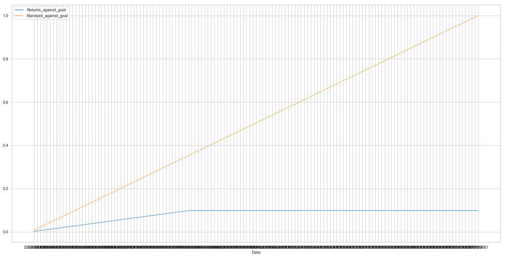

```python
# 누적 달성률과 기준 달성률을 시각화합니다.

plt.figure(figsize=[24,12])

sns.lineplot(data=df_park[['Returns_against_goal', 'Standard_against_goal']], palette="tab10", linewidth=1)
```

**멤버 박찬욱의 일일 성과 분석**

기준 달성률보다 일일 달성률이 낮습니다. 일정 기간 이후 성장 곡선이 멈춰있습니다. 면담, 전체 회의 등을 통해 목표를 재설정합니다.

### 데이터 로딩하기 - 성장 관리 마스터

**아직 작성 중..

```python
df = pd.read_csv("C:/Users/PC/Desktop/Editors\growth/Editors_performance_management_master.csv")
print(df.shape)
df.head()
```

```
(5, 7)
```

|  | Name | Goal | Achievement_1 | Achievement_2 | Start_date | End_date | Returns_against_goal |
| --- | --- | --- | --- | --- | --- | --- | --- |
| 0 | 김용구 | 시나리오 글쓰기 능력을 키운다, 단편 시나리오를 쓴다. | 장편영화 6편 필사(60%) | 단편 시나리오 완성(40%) | 2019-08-14 | 2019-12-31 | NaN |
| 1 | 봉준호 | 장편 시나리오를 쓴다, 특수효과 영상 연출법을 배운다. | 장편 시나리오 완성(80%) | 특수효과 8장면 영상 연출법(20%) | 2019-08-14 | 2019-12-31 | NaN |
| 2 | 박찬욱 | 시나리오 글쓰기 능력을 키운다, 단편 시나리오를 쓴다. | 장편영화 3편 필사(50%) | 단편 시나리오 완성(50%) | 2019-08-15 | 2019-12-31 | NaN |
| 3 | 뤽 다르덴 | 페이크 다큐 형식의 광고 영상을 제작한다. | 페이크 다큐 형식 광고 영상 제작(100%) | NaN | 2019-08-15 | 2019-12-31 | NaN |
| 4 | 송강호 | 픽사에 애니메이터로 입사한다. | 픽사 애니메이터로 입사(100%) | NaN | 2019-08-15 | 2019-12-31 | NaN |

```python
pivot_park = df_park.pivot_table(values = 'performance', index = 'Achievement_1', aggfunc = ['sum', 'count'])
pivot_park
```

| Achievement_1 | sum performance | count performance |
| --- | --- | --- |
| 0 | 0.0 | 90 |
| 장편필사_1_아버지가방에들어간다 | 39445.0 | 49 |

```python
pivot_park.columns = ['sum','count']
pivot_park['Returns_against_goal'] = pivot_park['sum'] / 40233 * 0.1
performance_park = pivot_park
performance_park
```

| Achievement_1 | sum | count | Returns_against_goal |
| --- | --- | --- | --- |
| 0 | 0.0 | 90 | 0.000000 |
| 장편필사_1_아버지가방에들어간다 | 39445.0 | 49 | 0.098041 |

```python
park_score = performance_park['Returns_against_goal'].sum()
park_score
```

```
0.09804140879377626
```

```python
df.loc[df.Name =='박찬욱', 'Returns_against_goal'] = park_score
df.head()
```

|  | Name | Goal | Achievement_1 | Achievement_2 | Start_date | End_date | Returns_against_goal |
| --- | --- | --- | --- | --- | --- | --- | --- |
| 0 | 김용구 | 시나리오 글쓰기 능력을 키운다, 단편 시나리오를 쓴다. | 장편영화 6편 필사(60%) | 단편 시나리오 완성(40%) | 2019-08-14 | 2019-12-31 | NaN |
| 1 | 봉준호 | 장편 시나리오를 쓴다, 특수효과 영상 연출법을 배운다. | 장편 시나리오 완성(80%) | 특수효과 8장면 영상 연출법(20%) | 2019-08-14 | 2019-12-31 | NaN |
| 2 | 박찬욱 | 시나리오 글쓰기 능력을 키운다, 단편 시나리오를 쓴다. | 장편영화 3편 필사(50%) | 단편 시나리오 완성(50%) | 2019-08-15 | 2019-12-31 | 0.098041 |
| 3 | 뤽 다르덴 | 페이크 다큐 형식의 광고 영상을 제작한다. | 페이크 다큐 형식 광고 영상 제작(100%) | NaN | 2019-08-15 | 2019-12-31 | NaN |
| 4 | 송강호 | 픽사에 애니메이터로 입사한다. | 픽사 애니메이터로 입사(100%) | NaN | 2019-08-15 | 2019-12-31 | NaN |